# EC_TCGA_vs_gnomAD

Olga Kondrashova

July 23, 2020

# Filtering gnomAD variants by consequence

This analysis is done as part of the case-control endometrial cancer study in collaboration with Mandy Spurdle. Repeating Jannah Shamsani’s PhD thesis experiment with version 2.1 of gnomAD data.

Filtering will include:  
* Predicted truncating variants^  
* Pathogenic/likely pathogenic based on ClinVar assertions.

^Predicted truncating variants are nonsense, frameshift indels, native splice donor or acceptor sites (dinucleotide consensus region).

First read in RefSeq transcript ids to use (used the latest versions - as determined by VEP annotations).

```r
df_refseq_ids <- fread("data/supporting/genomic_coordinates_30genes_ensemble_hg19.csv")


manual_vars <- scan("data/supporting/Variants_to_include_manual_annotation_2020Aug.txt",
    character())

trunc_filter <- "splice_acceptor_variant|splice_donor_variant|frameshift_variant|stop_gained"
noncoding_filter <- c("3_prime_UTR_variant", "5_prime_UTR_variant", "downstream_gene_variant",
    "upstream_gene_variant")
```

```r
filter_trunc_variants <- function(df){
  df %>%
    filter(!SYMBOL %in% c("POLE","POLD1")) %>%
    filter((SYMBOL == "PMS2" & !((Pos_start > 6010505 & Pos_start < 6027301) |
                                   (Pos_start > 6031553 & Pos_start < 6031738))) |
             SYMBOL != "PMS2" ) %>% # Manual filter, was too difficult to do with dataframe
    # select fs and ns (exclude last exon) and splice site variants only
    filter((str_detect(Consequence,
                       "frameshift_variant|stop_gained") & Last_exon != "yes") |
             str_detect(Consequence,"splice_acceptor_variant|splice_donor_variant")) %>%
    #has to not include "benign" in the clin sig. description
    filter(!str_detect(ClinVar_CLNSIG,
                       fixed("benign", ignore_case = T)))
}

filter_clinvar_variants <- function(df, noncoding_filter = noncoding_filter){
  df %>%
    filter(!SYMBOL %in% c("POLE","POLD1")) %>%
    filter((SYMBOL == "PMS2" & !((Pos_start > 6010505 & Pos_start < 6027301) |
                                   (Pos_start > 6031553 & Pos_start < 6031738))) |
             SYMBOL != "PMS2" ) %>% # Manual filter, was too difficult to do with dataframe
    # exclude non-coding region variants
    filter(!Consequence %in%  noncoding_filter) %>%
    #has to contain "pathogenic" in the clin sig. description
    #and not include "conflicting" in the clin sig. description
    #and exclude variants that have "no_assertion_criteria_provided"
    #or include variants that have been manually curated
    filter((str_detect(ClinVar_CLNSIG,
                      fixed("pathogenic", ignore_case = T)) &
             !str_detect(ClinVar_CLNSIG,
                         fixed("conflicting", ignore_case = T)) &
             !str_detect(ClinVar_CLNREVSTAT,
                         "no_assertion_criteria_provided")) |
             HGVSc %in% manual_vars)
}

filter_non_clinvar <- function(df,  genes = "MMR"){
  if (genes == "MMR") {
    df %<>%
      filter(SYMBOL %in% c("PMS2","MLH1","MSH2","MSH6")) %>%
      filter((SYMBOL == "PMS2" & !((Pos_start > 6010505 & Pos_start < 6027301) |
                                     (Pos_start > 6031553 & Pos_start < 6031738))) |
               SYMBOL != "PMS2" )
  } else if (genes == "MUTYH"){
    df %<>%
      filter(SYMBOL == "MUTYH")
  }
  df %>%
    # exclude non-coding region variants
    filter( str_detect(Consequence,"missense_variant")) %>%
    #has to contain "pathogenic" in the clin sig. description
    #and not include "conflicting" in the clin sig. description
    #and exclude variants that have "no_assertion_criteria_provided"
    filter(ClinVar_CLNSIG == "-")
}

filter_POLE_POLD1_variants <- function(df){
  df %>%
    filter(SYMBOL %in% c("POLE","POLD1")) %>%
    # include only missense variants
    filter(str_detect(Consequence,"missense_variant")) %>%
    #has to contain "pathogenic" in the clin sig. description
    #and not include "conflicting" in the clin sig. description
    #and exclude variants that have "no_assertion_criteria_provided"
    filter(str_detect(ClinVar_CLNSIG,
                      fixed("pathogenic", ignore_case = T)) &
             !str_detect(ClinVar_CLNSIG,
                         fixed("conflicting", ignore_case = T)) &
             !str_detect(ClinVar_CLNREVSTAT,
                         "no_assertion_criteria_provided"))
}
```

## gnomAD exomes

Read in VEP annotated gnomAD exome variants for selected 30 genes.  
Pre-filtered already by RefSeq IDs using python script *filter_VEP_step1.py*.  
(Filter by relevant RefSeq transcripts, preferred transcript in ClinVar - taken from Jannah Shamsani’s thesis)

```r
df_exomes <- fread("data/gnomad/gnomad.exomes.r2.1.1.genes30.vep.refseq.tsv.gz",
    skip = "#Uploaded_variation", check.names = TRUE) %>% mutate_at(.vars = c("gnomADe_non_cancer_AC_nfe",
    "gnomADe_non_cancer_AN_nfe", "gnomADe_non_cancer_nhomalt_nfe", "gnomADg_AC_nfe",
    "gnomADg_AN_nfe", "gnomADg_nhomalt_nfe"), funs(as.numeric(.)))
```

```r
df_exomes %<>% separate(Location, into = c("Pos_chr", "Pos_coord"), sep = "[:]",
    remove = FALSE) %>% separate(Pos_coord, into = c("Pos_start"), sep = "-", extra = "drop") %>%
    separate(EXON, into = c("EXON_Var", "EXON_Count"), sep = "/", remove = FALSE,
        fill = "right") %>% mutate(Last_exon = if_else(EXON_Var == EXON_Count, "yes",
    "no"))
```

Select all predicted truncating - nonsense & frameshift indels (exclude last exon), native splice donor or acceptor sites (dinucleotide consensus region).  
Remove variants not found in nfe non-cancer population (excludes TCGA).

```r
df_exomes_trunc <- df_exomes %>% filter(gnomADe_non_cancer_AC_nfe != 0) %>% filter_trunc_variants(.)
```

Then select ClinVar variants - likely pathogenic or pathogenic.  
Only taking variants without conflicting information & some level of assertion.  
Remove variants not found in nfe non-cancer population (excludes TCGA).

```r
df_exomes_clinvar <- df_exomes %>% filter(gnomADe_non_cancer_AC_nfe != 0) %>% filter_clinvar_variants(.,
    noncoding_filter)
```

Applying a separate filter for POLE & POLD1 variants as interested only in missense variants

```r
df_exomes_POLE_POLD1 <- df_exomes %>% filter(gnomADe_non_cancer_AC_nfe != 0) %>%
    filter_POLE_POLD1_variants(.)
```

As control number of alleles using max allele number per gene (as Jannah used in PhD thesis) before filtering by variants of interest variants.

```r
df_exomes_AN <- df_exomes %>% group_by(SYMBOL) %>% summarise(median_AN_nfe = median(gnomADe_non_cancer_AN_nfe),
    max_AN_nfe = max(gnomADe_non_cancer_AN_nfe))
```

Combine truncating and ClinVar classified variants.

```r
#combine truncating and clinvar classified variants
df_exomes_merged <- bind_rows(df_exomes_trunc,df_exomes_clinvar, df_exomes_POLE_POLD1) %>%
  distinct() %>%
  #group by gene
  group_by(SYMBOL) %>%
  summarise(
    #sum up the alternative allele count
    sum_AC_nfe = sum(gnomADe_non_cancer_AC_nfe),
    # add up all homozygous carriers (individuals, not alleles)
    sum_hom_nfe = sum(gnomADe_non_cancer_nhomalt_nfe)) %>%
  full_join(df_exomes_AN, by = "SYMBOL") %>%
  replace(is.na(.),0) %>%
  mutate(
    #count total number of carriers
    #(remove one of hom. allele, so that hom. carriers are not counted twice)
    carrier_nfe = sum_AC_nfe-sum_hom_nfe,
    #calculate total number of individuals
    #(need to round down as used max above, so may not divide cleanly)
    total_nfe = as.integer(max_AN_nfe/2),
    #calculate the allele frequency
    freq_AF_nfe = round(sum_AC_nfe/max_AN_nfe,4),
    #calculate frequency of carriers
    freq_carrier_nfe = round(carrier_nfe/total_nfe,4))
```

## gnomAD genomes

Read in VEP annotated gnomAD genome variants for selected 30 genes.  
Pre-filtered already by refseq ids using python script *filter_VEP_step1.py*.

```r
df_genomes <- fread("data/gnomad/gnomad.genomes.r2.1.1.genes30.vep.refseq.tsv.gz",
    skip = "#Uploaded_variation", check.names = TRUE) %>% mutate_at(.vars = c("gnomADe_non_cancer_AC_nfe",
    "gnomADe_non_cancer_AN_nfe", "gnomADe_non_cancer_nhomalt_nfe", "gnomADg_AC_nfe",
    "gnomADg_AN_nfe", "gnomADg_nhomalt_nfe"), funs(as.numeric(.)))
df_genomes %<>% separate(Location, into = c("Pos_chr", "Pos_coord"), sep = "[:]",
    remove = FALSE) %>% separate(Pos_coord, into = c("Pos_start"), sep = "-", extra = "drop") %>%
    separate(EXON, into = c("EXON_Var", "EXON_Count"), sep = "/", remove = FALSE,
        fill = "right") %>% mutate(Last_exon = if_else(EXON_Var == EXON_Count, "yes",
    "no"))
```

First select all presumed truncating - nonsense & frameshift indels (exclude last exon), native splice donor or acceptor sites (dinucleotide consensus region).  
Remove variants not found in nfe population.

```r
df_genomes_trunc <- df_genomes %>% filter(gnomADg_AC_nfe != 0) %>% filter_trunc_variants(.)
```

Then select ClinVar variants - likely pathogenic or pathogenic.  
Only taking variants without conflicting information & some level of assertion.  
Remove variants not found in nfe population.

```r
df_genomes_clinvar <- df_genomes %>% filter(gnomADg_AC_nfe != 0) %>% filter_clinvar_variants(.,
    noncoding_filter)
```

Separate filter for POLE & POLD1 variants.

```r
df_genomes_POLE_POLD1 <- df_genomes %>% filter(gnomADg_AC_nfe != 0) %>% filter_POLE_POLD1_variants(.)
```

As described in **gnomAD exome** section, decided to take a max allele (also calculate median) number per gene before filtering by variants of interest variants (but after filtering by transcript ID).

```r
df_genomes_AN <- df_genomes %>% group_by(SYMBOL) %>% summarise(median_AN_nfe = median(gnomADg_AN_nfe),
    max_AN_nfe = max(gnomADg_AN_nfe))
```

Combine truncating and ClinVar classified variants.

```r
#combine truncating and clinvar classified variants
df_genomes_merged <- rbind(df_genomes_trunc,df_genomes_clinvar,df_genomes_POLE_POLD1) %>%
  distinct() %>%
  group_by(SYMBOL) %>% #group by gene
  summarise(
    #sum up the alternative allele count
    sum_AC_nfe = sum(gnomADg_AC_nfe),
    # add up all homozygous carriers (individuals, not alleles)
    sum_hom_nfe = sum(gnomADg_nhomalt_nfe)) %>%
  full_join(df_genomes_AN, by = "SYMBOL") %>%
  replace(is.na(.),0) %>%
  mutate(
    #count total number of carriers
    #(remove one of hom. allele, so that hom. carriers are not counted twice)
    carrier_nfe = sum_AC_nfe-sum_hom_nfe,
    #calculate total number of individuals
    #(need to round down as used median above, so may not divide cleanly)
    total_nfe = as.integer(max_AN_nfe/2),
    #calculate the allele frequency
    freq_AF_nfe = round(sum_AC_nfe/max_AN_nfe,4),
    #calculate frequency of carriers
    freq_carrier_nfe = round(carrier_nfe/total_nfe,4))
```

## Combining gnomAD exome and genome tables

Sum up all values and recalculate frequencies.

```r
df_gnomad_merged <- df_exomes_merged %>%
  full_join(df_genomes_merged, by = "SYMBOL",suffix = c("_e","_g")) %>%
 # select(-contains("freq")) %>%
  mutate(sum_AC_nfe = sum_AC_nfe_e + sum_AC_nfe_g,
         sum_hom_nfe = sum_hom_nfe_e + sum_hom_nfe_g,
         sum_AN_nfe = max_AN_nfe_e + max_AN_nfe_g,
         carrier_nfe = carrier_nfe_e + carrier_nfe_g,
         total_nfe = total_nfe_e + total_nfe_g,
         #calculate the allele frequency
         freq_AF_nfe = round(sum_AC_nfe/sum_AN_nfe,4),
         #calculate frequency of carriers
         freq_carrier_nfe = round(carrier_nfe/total_nfe,4))

df_gnomad_merged %>%
  write_tsv(.,"./tables/gnomAD_total_counts_and_freq.tsv")

cat("Final combined (exome and genome) frequency table\n")
```

```
Final combined (exome and genome) frequency table
```

```r
kable(df_gnomad_merged) %>%
  kable_styling(bootstrap_options = c("striped", "hover", "condensed", "responsive"))
```

| SYMBOL | sum_AC_nfe_e | sum_hom_nfe_e | median_AN_nfe_e | max_AN_nfe_e | carrier_nfe_e | total_nfe_e | freq_AF_nfe_e | freq_carrier_nfe_e | sum_AC_nfe_g | sum_hom_nfe_g | median_AN_nfe_g | max_AN_nfe_g | carrier_nfe_g | total_nfe_g | freq_AF_nfe_g | freq_carrier_nfe_g | sum_AC_nfe | sum_hom_nfe | sum_AN_nfe | carrier_nfe | total_nfe | freq_AF_nfe | freq_carrier_nfe |
| --- | --- | --- | --- | --- | --- | --- | --- | --- | --- | --- | --- | --- | --- | --- | --- | --- | --- | --- | --- | --- | --- | --- | --- |
| AKT1 | 4 | 0 | 102020 | 102752 | 4 | 51376 | 0.0000 | 0.0001 | 0 | 0 | 15406 | 15436 | 0 | 7718 | 0.0000 | 0.0000 | 4 | 0 | 118188 | 4 | 59094 | 0.0000 | 0.0001 |
| APC | 44 | 0 | 102210 | 102744 | 44 | 51372 | 0.0004 | 0.0009 | 6 | 0 | 15420 | 15436 | 6 | 7718 | 0.0004 | 0.0008 | 50 | 0 | 118180 | 50 | 59090 | 0.0004 | 0.0008 |
| ATM | 247 | 0 | 102418 | 102740 | 247 | 51370 | 0.0024 | 0.0048 | 37 | 0 | 15416 | 15436 | 37 | 7718 | 0.0024 | 0.0048 | 284 | 0 | 118176 | 284 | 59088 | 0.0024 | 0.0048 |
| BRCA1 | 116 | 0 | 102406 | 102754 | 116 | 51377 | 0.0011 | 0.0023 | 24 | 0 | 15386 | 15436 | 24 | 7718 | 0.0016 | 0.0031 | 140 | 0 | 118190 | 140 | 59095 | 0.0012 | 0.0024 |
| BRCA2 | 160 | 0 | 102154 | 102722 | 160 | 51361 | 0.0016 | 0.0031 | 22 | 0 | 15420 | 15436 | 22 | 7718 | 0.0014 | 0.0029 | 182 | 0 | 118158 | 182 | 59079 | 0.0015 | 0.0031 |
| BRIP1 | 108 | 0 | 102494 | 102744 | 108 | 51372 | 0.0011 | 0.0021 | 15 | 0 | 15412 | 15436 | 15 | 7718 | 0.0010 | 0.0019 | 123 | 0 | 118180 | 123 | 59090 | 0.0010 | 0.0021 |
| CHEK2 | 796 | 2 | 100130 | 102750 | 794 | 51375 | 0.0077 | 0.0155 | 310 | 5 | 15404 | 15436 | 305 | 7718 | 0.0201 | 0.0395 | 1106 | 7 | 118186 | 1099 | 59093 | 0.0094 | 0.0186 |
| EPCAM | 31 | 0 | 101714 | 102748 | 31 | 51374 | 0.0003 | 0.0006 | 1 | 0 | 15374 | 15436 | 1 | 7718 | 0.0001 | 0.0001 | 32 | 0 | 118184 | 32 | 59092 | 0.0003 | 0.0005 |
| FAN1 | 144 | 0 | 101680 | 102754 | 144 | 51377 | 0.0014 | 0.0028 | 42 | 0 | 15424 | 15436 | 42 | 7718 | 0.0027 | 0.0054 | 186 | 0 | 118190 | 186 | 59095 | 0.0016 | 0.0031 |
| FANCC | 86 | 0 | 102398 | 102754 | 86 | 51377 | 0.0008 | 0.0017 | 18 | 0 | 15424 | 15436 | 18 | 7718 | 0.0012 | 0.0023 | 104 | 0 | 118190 | 104 | 59095 | 0.0009 | 0.0018 |
| MLH1 | 33 | 0 | 102554 | 102754 | 33 | 51377 | 0.0003 | 0.0006 | 1 | 0 | 15420 | 15436 | 1 | 7718 | 0.0001 | 0.0001 | 34 | 0 | 118190 | 34 | 59095 | 0.0003 | 0.0006 |
| MSH2 | 9 | 0 | 102416 | 102748 | 9 | 51374 | 0.0001 | 0.0002 | 2 | 0 | 15404 | 15436 | 2 | 7718 | 0.0001 | 0.0003 | 11 | 0 | 118184 | 11 | 59092 | 0.0001 | 0.0002 |
| MSH6 | 97 | 0 | 102252 | 102754 | 97 | 51377 | 0.0009 | 0.0019 | 37 | 0 | 15404 | 15436 | 37 | 7718 | 0.0024 | 0.0048 | 134 | 0 | 118190 | 134 | 59095 | 0.0011 | 0.0023 |
| MUTYH | 905 | 3 | 102530 | 102754 | 902 | 51377 | 0.0088 | 0.0176 | 121 | 0 | 15414 | 15436 | 121 | 7718 | 0.0078 | 0.0157 | 1026 | 3 | 118190 | 1023 | 59095 | 0.0087 | 0.0173 |
| NBN | 75 | 0 | 102379 | 102708 | 75 | 51354 | 0.0007 | 0.0015 | 14 | 0 | 15422 | 15436 | 14 | 7718 | 0.0009 | 0.0018 | 89 | 0 | 118144 | 89 | 59072 | 0.0008 | 0.0015 |
| NTHL1 | 239 | 0 | 101486 | 102746 | 239 | 51373 | 0.0023 | 0.0047 | 29 | 0 | 15410 | 15434 | 29 | 7717 | 0.0019 | 0.0038 | 268 | 0 | 118180 | 268 | 59090 | 0.0023 | 0.0045 |
| PALB2 | 82 | 0 | 102666 | 102752 | 82 | 51376 | 0.0008 | 0.0016 | 3 | 0 | 15410 | 15436 | 3 | 7718 | 0.0002 | 0.0004 | 85 | 0 | 118188 | 85 | 59094 | 0.0007 | 0.0014 |
| PIK3CA | 2 | 0 | 99557 | 102242 | 2 | 51121 | 0.0000 | 0.0000 | 1 | 0 | 15414 | 15436 | 1 | 7718 | 0.0001 | 0.0001 | 3 | 0 | 117678 | 3 | 58839 | 0.0000 | 0.0001 |
| PMS2 | 60 | 0 | 101985 | 102754 | 60 | 51377 | 0.0006 | 0.0012 | 16 | 0 | 15350 | 15436 | 16 | 7718 | 0.0010 | 0.0021 | 76 | 0 | 118190 | 76 | 59095 | 0.0006 | 0.0013 |
| PTEN | 19 | 0 | 101972 | 102754 | 19 | 51377 | 0.0002 | 0.0004 | 8 | 0 | 15412 | 15436 | 8 | 7718 | 0.0005 | 0.0010 | 27 | 0 | 118190 | 27 | 59095 | 0.0002 | 0.0005 |
| RAD51C | 59 | 0 | 102606 | 102750 | 59 | 51375 | 0.0006 | 0.0011 | 2 | 0 | 15388 | 15436 | 2 | 7718 | 0.0001 | 0.0003 | 61 | 0 | 118186 | 61 | 59093 | 0.0005 | 0.0010 |
| RINT1 | 50 | 0 | 102415 | 102752 | 50 | 51376 | 0.0005 | 0.0010 | 5 | 0 | 15398 | 15436 | 5 | 7718 | 0.0003 | 0.0006 | 55 | 0 | 118188 | 55 | 59094 | 0.0005 | 0.0009 |
| SDHB | 20 | 0 | 102554 | 102742 | 20 | 51371 | 0.0002 | 0.0004 | 0 | 0 | 15418 | 15436 | 0 | 7718 | 0.0000 | 0.0000 | 20 | 0 | 118178 | 20 | 59089 | 0.0002 | 0.0003 |
| SDHC | 12 | 0 | 100154 | 102750 | 12 | 51375 | 0.0001 | 0.0002 | 2 | 0 | 15402 | 15436 | 2 | 7718 | 0.0001 | 0.0003 | 14 | 0 | 118186 | 14 | 59093 | 0.0001 | 0.0002 |
| SDHD | 6 | 0 | 102361 | 102754 | 6 | 51377 | 0.0001 | 0.0001 | 1 | 0 | 15418 | 15436 | 1 | 7718 | 0.0001 | 0.0001 | 7 | 0 | 118190 | 7 | 59095 | 0.0001 | 0.0001 |
| SEC23B | 171 | 0 | 102682 | 102752 | 171 | 51376 | 0.0017 | 0.0033 | 26 | 0 | 15420 | 15436 | 26 | 7718 | 0.0017 | 0.0034 | 197 | 0 | 118188 | 197 | 59094 | 0.0017 | 0.0033 |
| STK11 | 2 | 0 | 90993 | 102070 | 2 | 51035 | 0.0000 | 0.0000 | 0 | 0 | 15396 | 15436 | 0 | 7718 | 0.0000 | 0.0000 | 2 | 0 | 117506 | 2 | 58753 | 0.0000 | 0.0000 |
| TP53 | 18 | 0 | 102422 | 102754 | 18 | 51377 | 0.0002 | 0.0004 | 2 | 0 | 15382 | 15436 | 2 | 7718 | 0.0001 | 0.0003 | 20 | 0 | 118190 | 20 | 59095 | 0.0002 | 0.0003 |
| POLD1 | 0 | 0 | 96428 | 102748 | 0 | 51374 | 0.0000 | 0.0000 | 0 | 0 | 15380 | 15436 | 0 | 7718 | 0.0000 | 0.0000 | 0 | 0 | 118184 | 0 | 59092 | 0.0000 | 0.0000 |
| POLE | 0 | 0 | 102314 | 102754 | 0 | 51377 | 0.0000 | 0.0000 | 0 | 0 | 15420 | 15436 | 0 | 7718 | 0.0000 | 0.0000 | 0 | 0 | 118190 | 0 | 59095 | 0.0000 | 0.0000 |

## Saving ClinVar variant lists for manual review (combined exome and genome).

```r
# Save all ClinVar variants selected by current path/likely path criteria
bind_rows(df_exomes_trunc,df_exomes_clinvar, df_exomes_POLE_POLD1) %>%
  distinct() %>%
  select(HGVSc,SYMBOL,Consequence,
         gnomADe_non_cancer_AN_nfe,gnomADe_non_cancer_AC_nfe,
         gnomADg_AN_nfe,gnomADg_AC_nfe,
         contains("clinvar", ignore.case = T)) %>%
  full_join(bind_rows(df_genomes_trunc,df_genomes_clinvar,df_genomes_POLE_POLD1) %>%
              distinct() %>%
              select(HGVSc,SYMBOL,Consequence,
                     gnomADe_non_cancer_AN_nfe,gnomADe_non_cancer_AC_nfe,
                     gnomADg_AN_nfe,gnomADg_AC_nfe,
                     contains("clinvar", ignore.case = T))) %>%
  distinct() %>%
  write_tsv(.,"./tables/gnomAD_combined_variants.tsv")

# Save path/likely path ClinVar variants with no assertion
df_exomes %>%
  filter((SYMBOL == "PMS2" & !((Pos_start > 6010505 & Pos_start < 6027301) |
                                 (Pos_start > 6031553 & Pos_start < 6031738))) |
           SYMBOL != "PMS2" ) %>%
  select(HGVSc,SYMBOL,Consequence,
         gnomADe_non_cancer_AN_nfe,gnomADe_non_cancer_AC_nfe,
         gnomADg_AN_nfe,gnomADg_AC_nfe,
         contains("clinvar", ignore.case = T)) %>%
  full_join(df_genomes %>%
              filter((SYMBOL == "PMS2" & !((Pos_start > 6010505 & Pos_start < 6027301) |
                                             (Pos_start > 6031553 & Pos_start < 6031738))) |
                       SYMBOL != "PMS2" ) %>%
              select(HGVSc,SYMBOL,Consequence,
                     gnomADe_non_cancer_AN_nfe,gnomADe_non_cancer_AC_nfe,
                     gnomADg_AN_nfe,gnomADg_AC_nfe,
                     contains("clinvar", ignore.case = T))) %>%
  filter(gnomADe_non_cancer_AC_nfe !=0 & gnomADg_AC_nfe !=0) %>%
  # exclude fs, ns and splice site variants
  filter(!(str_detect(Consequence, trunc_filter))) %>%
  #remove all variants outside of coding region
  filter(!Consequence %in% noncoding_filter)  %>%
  #has to contain "pathogenic" in the clin sig. description
  filter(str_detect(ClinVar_CLNSIGA,fixed("pathogenic", ignore_case = T)) &
           #has to not include "conflicting" in the clin sig. description
           !str_detect(ClinVar_CLNSIG,fixed("conflicting", ignore_case = T)) &
           #select only variants that have "no_assertion_criteria_provided"
           str_detect(ClinVar_CLNREVSTAT,"no_assertion_criteria_provided"))  %>%
  write_tsv(.,"./tables/gnomAD_combined_ClinVar_no_assertion.tsv")

# Save path/likely path ClinVar variants with conflicting evidence
df_exomes %>%
  filter((SYMBOL == "PMS2" & !((Pos_start > 6010505 & Pos_start < 6027301) |
                                 (Pos_start > 6031553 & Pos_start < 6031738))) |
           SYMBOL != "PMS2" ) %>%
  select(HGVSc,SYMBOL,Consequence,
         gnomADe_non_cancer_AN_nfe,gnomADe_non_cancer_AC_nfe,
         gnomADg_AN_nfe,gnomADg_AC_nfe,
         contains("clinvar", ignore.case = T)) %>%
  full_join(df_genomes %>%
              filter((SYMBOL == "PMS2" & !((Pos_start > 6010505 & Pos_start < 6027301) |
                                             (Pos_start > 6031553 & Pos_start < 6031738))) |
                       SYMBOL != "PMS2" ) %>%
              select(HGVSc,SYMBOL,Consequence,
                     gnomADe_non_cancer_AN_nfe,gnomADe_non_cancer_AC_nfe,
                     gnomADg_AN_nfe,gnomADg_AC_nfe,
                     contains("clinvar", ignore.case = T))) %>%
  filter(gnomADe_non_cancer_AC_nfe !=0 & gnomADg_AC_nfe !=0) %>%
  # exclude fs, ns and splice site variants
  filter(!(str_detect(Consequence,trunc_filter))) %>%
  #remove all variants outside of coding region
  filter(!Consequence %in% noncoding_filter)  %>%
  #has to contain "pathogenic" in the clin sig.
  filter(str_detect(ClinVar_CLNSIGA,"Pathogenic|Likely_pathogenic") &
           #include only "conflicting" in the clin sig. description
           str_detect(ClinVar_CLNSIG,
                      fixed("conflicting", ignore_case = T))) %>%
  write_tsv(.,"./tables/gnomAD_combined_ClinVar_conflicting.tsv")
```

## TCGA UCEC cases

This data cannot be publicly shared because it requires ethics clearance.

Read in VEP annotated TCGA UCEC variants for selected 30 genes.  
Filter by relevant RefSeq transcripts.

```r
df_TCGA_sample_codes <- read_tsv("data/supporting/TCGA_UCEC_donor_info.txt")


df_TCGA <- list.files(path = "data/TCGA/", pattern = ".vep.refseq.tsv.gz$", recursive = F,
    full.names = T) %>% purrr::set_names(.) %>% map_dfr(~fread(., skip = "#Uploaded_variation",
    check.names = TRUE, colClasses = "character"), .id = "source") %>% mutate(file_name = str_remove(basename(source),
    ".vep.refseq.tsv.gz")) %>% mutate(file_name = str_replace(file_name, "_vs_",
    ".")) %>% separate(file_name, into = c("testDonorLabel", "testSampleLabel", "testBam",
    "case_id", "aliquot_id", "controlBam"), sep = "[.]") %>% left_join(df_TCGA_sample_codes)
```

```r
df_TCGA %<>% separate(Location, into = c("Pos_chr", "Pos_coord"), sep = "[:]", remove = FALSE) %>%
    separate(Pos_coord, into = c("Pos_start"), sep = "-", extra = "drop") %>% separate(EXON,
    into = c("EXON_Var", "EXON_Count"), sep = "/", remove = FALSE, fill = "right") %>%
    mutate(Last_exon = if_else(EXON_Var == EXON_Count, "yes", "no"))
```

Filter variants as in gnomAD sections.

```r
df_TCGA_trunc <- df_TCGA %>% filter_trunc_variants(.)
```

```r
df_TCGA_clinvar <- df_TCGA %>% filter_clinvar_variants(., noncoding_filter)
```

```r
df_TCGA_POLE_POLD1 <- df_TCGA %>% filter_POLE_POLD1_variants(.)
```

Combine truncating and ClinVar classified variants.

```r
# combine truncating and clinvar classified variants
df_TCGA_merged_temp <- rbind(df_TCGA_trunc, df_TCGA_clinvar, df_TCGA_POLE_POLD1) %>%
    distinct() %>% group_by(SYMBOL)  #group by gene


# Access germline MAF and check allele count by pulling out number of reads
# supporting variant and alt reads
df_TCGA_check_AC <- df_TCGA_merged_temp %>% # Change file name to ghcc maf file
mutate(source = str_replace(source, ".vep.refseq.tsv", ".ghcc.maf")) %>% mutate(source = str_replace(source,
    "data/TCGA", "/working/genomeinfo/share/analysis/TCGA_-_UCEC/MAFs")) %>% pull(source) %>%
    purrr::set_names(.) %>% # Read individual mafs
map_dfr(~fread(., skip = "Hugo_Symbol\t", check.names = TRUE, colClasses = "character"),
    .id = "source") %>% # Change file name back for merging dataframes later
mutate(source = str_replace(source, ".ghcc.maf", ".vep.refseq.tsv")) %>% mutate(source = str_replace(source,
    "/working/genomeinfo/share/analysis/TCGA_-_UCEC/MAFs", "data/TCGA")) %>% dplyr::rename(SYMBOL = Hugo_Symbol,
    Pos_start = Start_Position) %>% select(source, SYMBOL, Chromosome, Pos_start,
    CDS_Change, N_Depth, N_Ref_Count, N_Alt_Count) %>% # Pull out only variatns in the selected list
right_join(df_TCGA_merged_temp %>% select(SYMBOL, Pos_chr, Pos_start, Allele, source)) %>%
    # Calculate VAF, AC and hom_counts
mutate(VAF = as.numeric(N_Alt_Count)/as.numeric(N_Depth)) %>% mutate(AC_count = if_else(VAF <
    0.7, 1, 2)) %>% mutate(carrier_count = 1, hom_count = if_else(AC_count == 2,
    1, 0))
```

```r
df_TCGA_EU_ethnicity <- df_TCGA_sample_codes %>%
  filter(SNP_ethnicity == "European" |
           (SNP_ethnicity == "#N/A" & race =="white"))

df_TCGA_EU_ethnicity %>%
  select(testDonorPublicationID, project_id, race, SNP_ethnicity, primary_diagnosis) %>%
  mutate(SNP_ethnicity = str_replace(SNP_ethnicity, "#N/A","not available")) %>%
  write_tsv("./tables/TCGA_UCEC_eu_cases.tsv")

df_TCGA_merged <- df_TCGA_merged_temp %>%
  left_join(df_TCGA_check_AC) %>%
  filter(testDonorPublicationID %in% df_TCGA_EU_ethnicity$testDonorPublicationID) %>%
  select(SYMBOL, HGVSc,Consequence, testDonorPublicationID,
         carrier_count, AC_count, hom_count) %>%
  distinct() %>%
  group_by(SYMBOL) %>%
  summarise(
    #sum up carrier count
    carrier_eu = sum(carrier_count),
    sum_AC_eu = sum(AC_count),
    sum_hom_eu = sum(hom_count)) %>%
  mutate(
    # total number of individuals
    total_eu = 308,
    sum_AN_eu = total_eu*2,
    #calculate frequency of carriers
    freq_carrier_eu = round(carrier_eu/total_eu,4),
    freq_AF_eu = round(sum_AC_eu/sum_AN_eu,4))
```

Final carrier frequencies table for TCGA European cases:

```r
kable(df_TCGA_merged) %>% kable_styling(bootstrap_options = c("striped", "hover",
    "condensed", "responsive"))
```

| SYMBOL | carrier_eu | sum_AC_eu | sum_hom_eu | total_eu | sum_AN_eu | freq_carrier_eu | freq_AF_eu |
| --- | --- | --- | --- | --- | --- | --- | --- |
| BRCA1 | 1 | 1 | 0 | 308 | 616 | 0.0032 | 0.0016 |
| CHEK2 | 3 | 3 | 0 | 308 | 616 | 0.0097 | 0.0049 |
| FAN1 | 1 | 1 | 0 | 308 | 616 | 0.0032 | 0.0016 |
| MSH2 | 2 | 2 | 0 | 308 | 616 | 0.0065 | 0.0032 |
| MSH6 | 4 | 4 | 0 | 308 | 616 | 0.0130 | 0.0065 |
| MUTYH | 5 | 5 | 0 | 308 | 616 | 0.0162 | 0.0081 |
| NBN | 1 | 1 | 0 | 308 | 616 | 0.0032 | 0.0016 |
| NTHL1 | 2 | 2 | 0 | 308 | 616 | 0.0065 | 0.0032 |
| PALB2 | 1 | 1 | 0 | 308 | 616 | 0.0032 | 0.0016 |
| PMS2 | 1 | 1 | 0 | 308 | 616 | 0.0032 | 0.0016 |
| RAD51C | 3 | 3 | 0 | 308 | 616 | 0.0097 | 0.0049 |
| SEC23B | 1 | 1 | 0 | 308 | 616 | 0.0032 | 0.0016 |

```r
df_TCGA_merged %>% write_tsv(., "./tables/TCGA_total_counts_and_freq.tsv")
```

```r
final_table_TCGA_gnomAD <- df_gnomad_merged %>% left_join(df_TCGA_merged) %>% select(SYMBOL,
    carrier_eu, sum_hom_eu, total_eu, freq_carrier_eu, carrier_nfe, sum_hom_nfe,
    total_nfe, freq_carrier_nfe) %>% dplyr::rename(Gene = SYMBOL, N_carrier_TCGA = carrier_eu,
    N_hom_TCGA = sum_hom_eu, N_total_TCGA = total_eu, Freq_TCGA = freq_carrier_eu,
    N_carrier_gnomAD = carrier_nfe, N_hom_gnomAD = sum_hom_nfe, N_total_gnomAD = total_nfe,
    Freq_gnomAD = freq_carrier_nfe) %>% mutate(Freq_TCGA = Freq_TCGA * 100, Freq_gnomAD = Freq_gnomAD *
    100) %>% arrange(-N_carrier_TCGA, -Freq_TCGA, -N_carrier_gnomAD, Gene) %>% replace(is.na(.),
    0)


kable(final_table_TCGA_gnomAD) %>% kable_styling(bootstrap_options = c("striped",
    "hover", "condensed", "responsive"))
```

| Gene | N_carrier_TCGA | N_hom_TCGA | N_total_TCGA | Freq_TCGA | N_carrier_gnomAD | N_hom_gnomAD | N_total_gnomAD | Freq_gnomAD |
| --- | --- | --- | --- | --- | --- | --- | --- | --- |
| MUTYH | 5 | 0 | 308 | 1.62 | 1023 | 3 | 59095 | 1.73 |
| MSH6 | 4 | 0 | 308 | 1.30 | 134 | 0 | 59095 | 0.23 |
| CHEK2 | 3 | 0 | 308 | 0.97 | 1099 | 7 | 59093 | 1.86 |
| RAD51C | 3 | 0 | 308 | 0.97 | 61 | 0 | 59093 | 0.10 |
| NTHL1 | 2 | 0 | 308 | 0.65 | 268 | 0 | 59090 | 0.45 |
| MSH2 | 2 | 0 | 308 | 0.65 | 11 | 0 | 59092 | 0.02 |
| SEC23B | 1 | 0 | 308 | 0.32 | 197 | 0 | 59094 | 0.33 |
| FAN1 | 1 | 0 | 308 | 0.32 | 186 | 0 | 59095 | 0.31 |
| BRCA1 | 1 | 0 | 308 | 0.32 | 140 | 0 | 59095 | 0.24 |
| NBN | 1 | 0 | 308 | 0.32 | 89 | 0 | 59072 | 0.15 |
| PALB2 | 1 | 0 | 308 | 0.32 | 85 | 0 | 59094 | 0.14 |
| PMS2 | 1 | 0 | 308 | 0.32 | 76 | 0 | 59095 | 0.13 |
| ATM | 0 | 0 | 0 | 0.00 | 284 | 0 | 59088 | 0.48 |
| BRCA2 | 0 | 0 | 0 | 0.00 | 182 | 0 | 59079 | 0.31 |
| BRIP1 | 0 | 0 | 0 | 0.00 | 123 | 0 | 59090 | 0.21 |
| FANCC | 0 | 0 | 0 | 0.00 | 104 | 0 | 59095 | 0.18 |
| RINT1 | 0 | 0 | 0 | 0.00 | 55 | 0 | 59094 | 0.09 |
| APC | 0 | 0 | 0 | 0.00 | 50 | 0 | 59090 | 0.08 |
| MLH1 | 0 | 0 | 0 | 0.00 | 34 | 0 | 59095 | 0.06 |
| EPCAM | 0 | 0 | 0 | 0.00 | 32 | 0 | 59092 | 0.05 |
| PTEN | 0 | 0 | 0 | 0.00 | 27 | 0 | 59095 | 0.05 |
| SDHB | 0 | 0 | 0 | 0.00 | 20 | 0 | 59089 | 0.03 |
| TP53 | 0 | 0 | 0 | 0.00 | 20 | 0 | 59095 | 0.03 |
| SDHC | 0 | 0 | 0 | 0.00 | 14 | 0 | 59093 | 0.02 |
| SDHD | 0 | 0 | 0 | 0.00 | 7 | 0 | 59095 | 0.01 |
| AKT1 | 0 | 0 | 0 | 0.00 | 4 | 0 | 59094 | 0.01 |
| PIK3CA | 0 | 0 | 0 | 0.00 | 3 | 0 | 58839 | 0.01 |
| STK11 | 0 | 0 | 0 | 0.00 | 2 | 0 | 58753 | 0.00 |
| POLD1 | 0 | 0 | 0 | 0.00 | 0 | 0 | 59092 | 0.00 |
| POLE | 0 | 0 | 0 | 0.00 | 0 | 0 | 59095 | 0.00 |

```r
final_table_TCGA_gnomAD %>% write_tsv(., "./tables/TCGA_gnomAD_total_counts_and_freq.tsv")
```

```r
# Save all ClinVar variants selected by current path/likely path criteria
df_TCGA_merged_variants <- df_TCGA_merged_temp %>%
  select(HGVSc,SYMBOL,Pos_chr,Pos_start,Allele, aliquot_id, Consequence, testDonorPublicationID,
         contains("clinvar", ignore.case = T)) %>%
  distinct() %>%
  group_by(HGVSc,SYMBOL,Consequence) %>%
  mutate(TCGA_cases = paste0(testDonorPublicationID, collapse=";"),
         aliquot_id = paste0(aliquot_id, collapse = ";")) %>%
  select(-testDonorPublicationID, aliquot_id) %>%
  distinct() %>%
  write_tsv(.,"./tables/TCGA_variants.tsv")

# Same but for EU cases
df_TCGA_merged_variants_eu <- df_TCGA_merged_temp %>%
  filter(testDonorPublicationID %in% df_TCGA_EU_ethnicity$testDonorPublicationID) %>%
  select(HGVSc,SYMBOL,Consequence, testDonorPublicationID,
         contains("clinvar", ignore.case = T)) %>%
  distinct() %>%
  group_by(HGVSc,SYMBOL,Consequence) %>%
  mutate(TCGA_eu_cases = paste0(testDonorPublicationID, collapse=";")) %>%
  select(-testDonorPublicationID) %>%
  distinct() %>%
  write_tsv(.,"./tables/TCGA_eu_variants.tsv")


# Save path/likely path ClinVar variants with no assertion
df_TCGA %>%
  filter((SYMBOL == "PMS2" & !((Pos_start > 6010505 & Pos_start < 6027301) |
                                 (Pos_start > 6031553 & Pos_start < 6031738))) |
           SYMBOL != "PMS2" ) %>%
  select(HGVSc,SYMBOL,Consequence,testDonorPublicationID,
         contains("clinvar", ignore.case = T)) %>%
  # exclude fs, ns and splice site variants
  filter(!(str_detect(Consequence, trunc_filter))) %>%
  #remove all variants outside of coding region
  filter(!Consequence %in% noncoding_filter)  %>%
  #has to contain "pathogenic" in the clin sig. description
  filter(str_detect(ClinVar_CLNSIGA,fixed("pathogenic", ignore_case = T)) &
           #has to not include "conflicting" in the clin sig. description
           !str_detect(ClinVar_CLNSIG,fixed("conflicting", ignore_case = T)) &
           #select only variants that have "no_assertion_criteria_provided"
           str_detect(ClinVar_CLNREVSTAT,"no_assertion_criteria_provided"))  %>%
    group_by(HGVSc,SYMBOL,Consequence) %>%
  mutate(case_id = paste0(testDonorPublicationID, collapse=";")) %>%
  select(-testDonorPublicationID) %>%
  distinct() %>%
  write_tsv(.,"./tables/TCGA_ClinVar_no_assertion.tsv")

# Save path/likely path ClinVar variants with conflicting evidence
df_TCGA %>%
  filter((SYMBOL == "PMS2" & !((Pos_start > 6010505 & Pos_start < 6027301) |
                                 (Pos_start > 6031553 & Pos_start < 6031738))) |
           SYMBOL != "PMS2" ) %>%
  select(HGVSc,SYMBOL,Consequence, testDonorPublicationID,
         contains("clinvar", ignore.case = T)) %>%
  # exclude fs, ns and splice site variants
  filter(!(str_detect(Consequence,trunc_filter))) %>%
  #remove all variants outside of coding region
  filter(!Consequence %in% noncoding_filter)  %>%
  #has to contain "pathogenic" in the clin sig.
  filter(str_detect(ClinVar_CLNSIGA,
                    "Likely_pathogenic|Pathogenic") &
           #include only "conflicting" in the clin sig. description
           str_detect(ClinVar_CLNSIG,
                      fixed("conflicting", ignore_case = T))) %>%
    group_by(HGVSc,SYMBOL,Consequence) %>%
  mutate(case_id = paste0(testDonorPublicationID, collapse=";")) %>%
  select(-testDonorPublicationID) %>%
  distinct() %>%
  write_tsv(.,"./tables/TCGA_ClinVar_conflicting_tsv")
```

Supp table - variants list

```r
# Save all ClinVar variants selected by current path/likely path criteria
bind_rows(df_exomes_trunc, df_exomes_clinvar, df_exomes_POLE_POLD1) %>% distinct() %>%
    select(HGVSc, SYMBOL, Consequence, gnomADe_non_cancer_AC_nfe, gnomADe_non_cancer_nhomalt_nfe,
        gnomADg_AC_nfe, gnomADg_nhomalt_nfe) %>% full_join(bind_rows(df_genomes_trunc,
    df_genomes_clinvar, df_genomes_POLE_POLD1) %>% distinct() %>% select(HGVSc, SYMBOL,
    Consequence, gnomADe_non_cancer_AC_nfe, gnomADe_non_cancer_nhomalt_nfe, gnomADg_AC_nfe,
    gnomADg_nhomalt_nfe)) %>% distinct() %>% replace(is.na(.), 0) %>% mutate(gnomAD_nfe_exome = gnomADe_non_cancer_AC_nfe -
    gnomADe_non_cancer_nhomalt_nfe, gnomAD_nfe_genome = gnomADg_AC_nfe - gnomADg_nhomalt_nfe) %>%
    full_join(df_TCGA_merged_variants %>% select(HGVSc, SYMBOL, Consequence, TCGA_cases)) %>%
    full_join(df_TCGA_merged_variants_eu %>% select(HGVSc, SYMBOL, Consequence, TCGA_eu_cases)) %>%
    replace(is.na(.), 0) %>% select(-c(gnomADe_non_cancer_AC_nfe, gnomADe_non_cancer_nhomalt_nfe,
    gnomADg_AC_nfe, gnomADg_nhomalt_nfe)) %>% arrange(SYMBOL, HGVSc) %>% write_tsv(.,
    "./tables/TCGA_gnomAD_all_variants.tsv")
```

# Somatic mutational signature analysis

This section is looking at the mutational signatures in cases with germline variants.

## TCGA Signatures

```r
vars_list <- df_TCGA_merged_variants %>% ungroup() %>% separate_rows(aliquot_id,
    TCGA_cases, sep = ";") %>% select(HGVSc, SYMBOL, Pos_chr, Pos_start, Allele,
    aliquot_id, TCGA_cases) %>% mutate_at(c("aliquot_id", "TCGA_cases"), ~str_trim(.))
```

Read in all MAF files.

```r
filenames <- list.files(path = "./data/MAFs", pattern = ".shc.maf.gz$", recursive = F,
    full.names = T)


maf_shc <- data.frame()
for (i in filenames) {
    sample_id <- strsplit(basename(i), split = "[.]")[[1]][4]  #normal sample ID
    if (sample_id %in% vars_list$aliquot_id) {
        maf_shc <- rbind(maf_shc, read_tsv(i, comment = "#", col_types = cols(.default = "c")))
    }
}

maf_shc %<>% separate(Tumor_Sample_Barcode, into = c("case_submitter_id", "aliquot_id"),
    sep = ":", remove = FALSE, extra = "drop") %>% filter(!aliquot_id %in% c("5b259ecb-d09b-40d4-9f46-3585ab178e52",
    "851870d9-cd58-42d8-9cb4-f785b62aa0bd"))  # filter 2 samples that have double tumour/normal pairs.
```

```r
filenames <- list.files(path = "./data/MAFs", pattern = ".ghcc.maf.gz$", recursive = F,
    full.names = T)


maf_ghcc <- data.frame()
for (i in filenames) {
    sample_id <- strsplit(basename(i), split = "[.]")[[1]][4]  #normal sample ID
    if (sample_id %in% vars_list$aliquot_id) {
        maf_ghcc %<>% bind_rows(read_tsv(i, comment = "#", col_types = cols(.default = "c")))
    }
}

maf_ghcc %<>% separate(Tumor_Sample_Barcode, into = c("case_submitter_id", "aliquot_id"),
    sep = ":", remove = FALSE, extra = "drop") %>% filter(!aliquot_id %in% c("5b259ecb-d09b-40d4-9f46-3585ab178e52",
    "851870d9-cd58-42d8-9cb4-f785b62aa0bd")) %>% # filter 2 samples that have double tumour/normal pairs.
separate(Matched_Norm_Sample_Barcode, into = c("case_submitter_id", "normal_aliquot_id"),
    sep = ":", remove = FALSE, extra = "drop")

sample_list <- vars_list %>% left_join(maf_ghcc %>% select(case_submitter_id, normal_aliquot_id) %>%
    distinct(), by = c(aliquot_id = "normal_aliquot_id")) %>% select(case_submitter_id,
    TCGA_cases)
```

Read in msi sensor outputs.

```r
msi_data <- list.files(path = "./data/msi_sensor", full.names = T) %>% purrr::set_names(. %>%
    basename()) %>% map_dfr(~read_tsv(., col_types = cols()), .id = "name") %>% separate(name,
    c("case_submitter_id", "aliquot_id"), sep = "_", remove = FALSE) %>% filter(aliquot_id %in%
    maf_shc$aliquot_id) %>% left_join(sample_list)
```

Read in library capture information.

```r
capture_info <- read_tsv("./data/supporting/TCGA_-_endometrial_cancer.StudyPairedAnalysis.tsv",
    col_types = cols()) %>% select(testSampleLabel, testCaptureKit)
```

Define *deconstructSigs* and *combine_plot* functions.

```r
run_deconstructsigs <- function(data,out_path,out_name,signatures, method = "default", plot=FALSE, cutoff=0.15) {
  # Run deconstructSigs on all samples
  for (i in 1:nrow(data)){
    sample_id=row.names(data[i,])
    sigs= whichSignatures(tumor.ref = data,
                          signatures.ref = signatures,
                          sample.id = sample_id,
                          signature.cutoff = cutoff,
                          contexts.needed = TRUE,
                          tri.counts.method = method)
    # Plot signatures if defined
    if ( isTRUE(plot)){
      pdf(paste0(out_path,"figures/",sample_id,"_",method,"_",out_name,".pdf"))
      plotSignatures(sigs)
      dev.off()
    }
    # Combine sig assignments for samples to one dataframe
    if (exists("sigs_final")) {
      sigs_final <- rbind(sigs_final,sigs$weights)
    } else {
      sigs_final <- sigs$weights
    }
  }
  # Subset only detected signatures
  sigs_detected <- sigs_final %>%
    rownames_to_column(var="Sample")%>%
    gather(Sig, Count, -Sample) %>%
    group_by(Sig) %>%
    filter(Count > 0) %>%
    spread(Sig, Count, fill = 0)
  # Return signature assigment dataframe
  write.table(sigs_detected, paste0(out_path,"tables/",method,"_",out_name,".tsv"),quote = F, sep = "\t", row.names = F)
  return(sigs_detected)
}


combined_plot <- function(gvar,sig,sig2 = NULL,tmb,svar_POLE,msi,sample_order,
                          group_genes = NULL,sig_type = "pcawg", sig_type2 = "denovo") {
  if(sig_type == "cosmicv2"){
    sig_colours <- sig_colours_cosmicv2
  } else if (sig_type == "denovo" ){
    sig_colours <- sig_colours_denovo
  } else if (sig_type == "pcawg"){
    sig_colours <- sig_colours
  }
  if(sig_type2 == "cosmicv2"){
    sig_colours2 <- sig_colours_cosmicv2
  } else if (sig_type2 == "denovo" ){
    sig_colours2 <- sig_colours_denovo
  } else if (sig_type2 == "pcawg"){
    sig_colours2 <- sig_colours
  }

  if (is_tibble(group_genes)){
    p1 <- gvar %>%
      left_join(group_genes, by ="Gene") %>%
      filter(Sample %in% sample_order) %>%
      mutate(Sample = factor(Sample, levels = sample_order)) %>%
      mutate(Gene = factor(Gene, levels = group_genes$Gene)) %>%
      ggplot(.) +
      geom_tile(aes(y=Gene,x=Sample,fill=Type, colour = Enriched, width = 0.8, height = 0.8), size = 1) +
      facet_grid(Group~., scales="free_y", space = "free_y")

  } else{
  p1 <- gvar %>%
    filter(Sample %in% sample_order) %>%
    mutate(Sample = factor(Sample, levels = sample_order)) %>%
    ggplot(.) +
    geom_tile(aes(y=Gene,x=Sample,fill=Type, colour = Enriched, width = 0.8, height = 0.8), size = 1)
  }
  p1 <- p1 +
    scale_fill_manual(values = c("WT"="#d6d6d6",
                                 "Pathogenic"="#1e6dc0")) +
    #scale_fill_manual(values= mut_colours) +
    scale_colour_manual(values = c("yes"="#E8294A","white")) +
    guides(color = guide_legend(ncol = 1,
                                override.aes = list(fill=NA))) +
    theme_minimal(base_size = 11) + labs(x = "", y = "", colour = "Enriched in tumour",
                                         fill = "Germline Status") +
    theme(axis.text.x=element_blank(),
          panel.grid.major.y = element_blank(),
          panel.grid.major.x = element_blank(),
          legend.position = "right",
          strip.text.y = element_blank())

  p2 <- sig %>%
    filter(Sample %in% sample_order) %>%
    mutate(Sample = factor(Sample, levels = sample_order)) %>%
    ggplot(.) +
    geom_bar(aes(x= Sample, y = Count, fill = Sig_full), stat = "identity", position = "stack") +
    labs(x="",y="Proportion",fill ="Signature (Aetiology)") +
    theme_minimal(base_size = 11) +
    scale_fill_manual(values = sig_colours) +
    guides(fill = guide_legend(ncol = 1)) +
    theme(axis.text.x=element_blank(),
          strip.text.x = element_text(size = 6),
          panel.grid.minor = element_blank(),
          #panel.grid.major.y = element_blank(),
          panel.grid.major.x = element_blank(),
          legend.position = "right")

  p3 <- tmb %>%
    filter(TCGA_cases %in% sample_order) %>%
    mutate(Sample = factor(TCGA_cases, levels = sample_order)) %>%
    ggplot(.)+
    geom_bar(aes(x= Sample, y = TMB, fill = "TMB"), stat = "identity") +
    labs(x="",y="Mutations per Mb",fill = "") +
    scale_y_log10()+
    theme_minimal(base_size = 11) +
    scale_fill_manual(values = "grey") +
    theme(axis.text.x=element_blank(),
          strip.text.x = element_text(size = 6),
          panel.grid.minor = element_blank(),
          #panel.grid.major.y = element_blank(),
          panel.grid.major.x = element_blank(),
          legend.position = "right")

  p4 <- svar_POLE %>%
    filter(TCGA_cases %in% sample_order) %>%
    mutate(Sample = factor(TCGA_cases, levels = sample_order)) %>%
    ggplot(.) +
    geom_tile(aes(y=Gene,x=Sample,fill=Variant_Classification, width = 0.8, height = 0.8), size = 1, colour="white") +
    scale_fill_manual(values= c("WT"="#d6d6d6",
                                "Mutation"="#1e6dc0",
                                 "Hom. Deletion" = "#C92E12",
                                 "Methylation" = "#2FD9C9")) +
    guides(color = guide_legend(ncol = 1)) +
    theme_minimal(base_size = 11) + labs(x = "", y = "", fill = "Somatic Status") +
    theme(axis.text.x=element_text(angle = 90, hjust = 1 , vjust = 0.5),
          panel.grid.minor = element_blank(),
          panel.grid.major.y = element_blank(),
          #panel.grid.major.x = element_blank(),
          legend.position = "right")

  p5 <- msi %>%
    filter(TCGA_cases %in% sample_order) %>%
    mutate(Sample = factor(TCGA_cases, levels = sample_order)) %>%
    mutate(MSI_threshold = if_else(`%`>=3.5,">=3.5","<3.5")) %>%
    ggplot(.)+
    geom_bar(aes(x=Sample,y=`%`, fill = MSI_threshold),stat="identity")+
    #geom_hline(yintercept=3.5,colour="black",linetype="dashed")+
    theme_minimal(base_size = 11) + labs(x = "", y = "MSI score (%)", fill = "MSIsensor threshold") +
    theme(axis.text.x=element_blank(),
          panel.grid.minor = element_blank(),
          #panel.grid.major.y = element_blank(),
          panel.grid.major.x = element_blank()
          )

  if (!is.null(sig2)){
    p6 <- sig2 %>%
      filter(Sample %in% sample_order) %>%
      mutate(Sample = factor(Sample, levels = sample_order)) %>%
      ggplot(.) +
      geom_bar(aes(x= Sample, y = Count, fill = Sig_full), stat = "identity", position = "stack") +
      labs(x="",y="Proportion",fill ="De novo Signature (Aetiology)") +
      theme_minimal(base_size = 11) +
      scale_fill_manual(values = sig_colours2) +
      guides(fill = guide_legend(ncol = 1)) +
      theme(axis.text.x=element_blank(),
            strip.text.x = element_text(size = 6),
            panel.grid.minor = element_blank(),
            #panel.grid.major.y = element_blank(),
            panel.grid.major.x = element_blank(),
            legend.position = "right")
    p_main <- plot_grid(p3, p5, p2, p6, p1, p4, align = "v",axis = 'lr', nrow = 6, rel_heights = c(1/6, 1/6, 1/3,  1/3, 1/3, 1/4))
  } else {
    p_main <- plot_grid(p3, p5, p2, p1, p4, align = "v",axis = 'lr', nrow = 5, rel_heights = c(1/6, 1/6, 1/3, 1/3, 1/4))
  }

  return(p_main)
}
```

Other supporting info.

```r
# Chromosome order
chr_levels = c("1", "2", "3", "4", "5", "6", "7", "8", "9", "10", "11", "12", "13",
    "14", "15", "16", "17", "18", "19", "20", "21", "22", "X", "Y")


sig_list_cosmicv2 <- c("Sig18 (MUTYH mut)", "Sig6 (MSI)", "Sig15 (MSI)", "Sig21 (MSI)",
    "Sig26 (MSI)", "Sig20 (MSI)", "Sig14 (POLE mut & MSI)", "Sig10 (POLE mut)", "Sig3 (HRD)",
    "Sig30 (NTHL1 mut)", "Sig13 (APOBEC)", "Sig2 (APOBEC)", "Sig1 (Age)", "Other")

sig_colours_cosmicv2 <- c("#c5ff1a", "#8d69a3", "#7a5093", "#541e75", "#420666",
    "#1f09ba", "#fa939e", "#f97886", "#943503", "#118866", "#3498db", "#57cef2",
    "#009999", "#8d958f")
names(sig_colours_cosmicv2) <- sig_list_cosmicv2

sig_list_denovo <- c("Sig D (MSI, Sig26)", "Sig C (MSI, Sig20)", "Sig E (POLE mut & MSI, Sig14)",
    "Sig A (POLE mut, Sig10)", "Sig F (APOBEC, Sig2)", "Sig B (Age, Sig1)")

sig_colours_denovo <- c("#420666", "#1f09ba", "#fa939e", "#f97886", "#3498db", "#009999")

names(sig_colours_denovo) <- sig_list_denovo



mut_colours <- c("#d6d6d6", "#90CAF9", "#FFAB91", "#CE93D8", "#80DEEA", "#E6EE9C",
    "#EC769F")

names(mut_colours) <- c("WT", "Nonsense", "Frame_Shift", "Missense", "Splice_Site",
    "In-frame_indel", "Frame_Shift;Missense")


p96_colours <- c("#30B3EA", "#000000", "#E40000", "#989797", "#93C700", "#F3ADBB")
names(p96_colours) <- c("C>A", "C>G", "C>T", "T>A", "T>C", "T>G")

col_fun_cosine <- colorRamp2(c(0, 0.5, 1), c("#F7F9DD", "#4DA563", "#022D50"))
```

## Tumour Mutation Burden analysis

```r
tmb_df <- maf_shc %>% left_join(capture_info, by = c(aliquot_id = "testSampleLabel")) %>%
    left_join(sample_list) %>% count(TCGA_cases, case_submitter_id, testCaptureKit) %>%
    mutate(captureSize = case_when(testCaptureKit == "hg18 nimblegen exome version 2" ~
        26.2, testCaptureKit == "Human All Exon 44Mb (SureSelect)" ~ 44, testCaptureKit ==
        "SeqCap EZ Human Exome Library v2.0 (Nimblegen)" ~ 36.5, testCaptureKit ==
        "SeqCap EZ Human Exome Library v3.0 (Nimblegen)" ~ 64)) %>% mutate(TMB = round(n/captureSize,
    2)) %>% arrange(-TMB)
```

## Subset by mutations

```r
som_variants <- maf_shc %>% left_join(capture_info, by = c(aliquot_id = "testSampleLabel")) %>%
    left_join(sample_list) %>% filter(Hugo_Symbol %in% df_refseq_ids$Gene) %>% mutate(T_Alt_Count = as.integer(T_Alt_Count),
    T_Depth = as.integer(T_Depth))

som_variants %>% write_tsv("./tables/somatic_variants.tsv")
```

## DeconstructSigs Mutational Signatures

Subset mafs by SNVs only, annotate and format for deconstructSigs.  
Filter samples with >= 100 variants.

```r
maf_shc_snv <- maf_shc %>% left_join(sample_list) %>% filter(Variant_Type == "SNP") %>%
    mutate(alt = ifelse(Reference_Allele == Tumor_Seq_Allele1, Tumor_Seq_Allele2,
        Tumor_Seq_Allele1)) %>% filter(Chromosome %in% chr_levels) %>% mutate(chr = paste0("chr",
    Chromosome)) %>% group_by(TCGA_cases) %>% filter(n() >= 100) %>% ungroup() %>%
    mutate(Start_Position = as.integer(Start_Position)) %>% select(TCGA_cases, chr,
    Start_Position, Reference_Allele, alt) %>% data.frame()  # deconstructSigs does not like tibbles

sigs_input <- mut.to.sigs.input(mut.ref = maf_shc_snv, sample.id = "TCGA_cases",
    chr = "chr", pos = "Start_Position", ref = "Reference_Allele", alt = "alt")
```

Read in Cosmic v2 signatures.

```r
cosmic_t <- read_delim("./data/supporting/signatures_probabilities.txt", delim = "\t")

cosmic_t %<>% select(1:33, -`Substitution Type`, -Trinucleotide) %>% arrange(match(`Somatic Mutation Type`,
    colnames(sigs_input))) %>% column_to_rownames(var = "Somatic Mutation Type") %>%
    as.matrix()

cosmic_sigs <- as.data.frame(t(cosmic_t)) %>% rownames_to_column(var = "Signature") %>%
    mutate(Signature = str_replace(Signature, "Signature ", "Sig")) %>% column_to_rownames(var = "Signature")
```

Convert to deconstructSigs matrix & run deconstructSigs (in exome mode).  
Using 0.15 signature cutoff.

```r
sig_exome_cosmic <- run_deconstructsigs(data = sigs_input, out_path = "./", out_name = "cosmicv2_sig_",
    signatures = cosmic_sigs, method = "exome", plot = F, cutoff = 0.15)
```

```r
sig_exome_cosmic_melt <- sig_exome_cosmic %>%
  mutate(Other = (1- rowSums(.[-1]))) %>% #Calculate up to 100%
  gather(Sig, Count, -Sample) %>%
  filter(Count != 0) %>%
  mutate(Sig_name = case_when(Sig == "Sig1" ~ "Age",
                              Sig == "Sig10" ~ "POLE mut",
                              Sig == "Sig13" ~ "APOBEC",
                              Sig == "Sig2" ~ "APOBEC",
                              Sig == "Sig14" ~ "POLE mut & MSI",
                              Sig == "Sig15" ~ "MSI",
                              Sig == "Sig20" ~ "MSI",
                              Sig == "Sig21" ~ "MSI",
                              Sig == "Sig26" ~ "MSI",
                              Sig == "Sig3" ~ "HRD",
                              Sig == "Sig30" ~ "NTHL1 mut",
                              Sig == "Sig6" ~ "MSI",
                              Sig == "Other" ~ "",
                              Sig == "Sig18" ~ "MUTYH mut")) %>%
  mutate(Sig_full = if_else(Sig == "Other", Sig, paste0(Sig," (",Sig_name,")")))

sig_exome_cosmic_melt %<>%
  mutate(Sig_full = factor(Sig_full, levels = rev(sig_list_cosmicv2)))

sig_exome_cosmic_melt %>%
  select(1:3) %>%
  arrange(Sample,-Count) %>%
  write_tsv(paste0("./tables/cosmicv2_sig_exome_melt.tsv"))
```

Create somatic variant subsets for POLE, MMR and other gene variants.

For POLE variant subset including all missense variants in exons 9-14 (except for c.1204T>C).  
Variant c.1204T>C is not reported in COSMIC, but reported in 6 alleles in gnomAD. More importantly, sample TCGA_UCEC_325 that has this variant does not have increase mutational burden or POLE signature - the only som POLE sample without signature.  
Manually found c.890C>T (p.S297F) hotspot mutation in TCGA_UCEC_064 that was filtered out due to low coverage.

```r
# Subset POLE variants only
som_variants_POLE <- som_variants %>% filter(Hugo_Symbol == "POLE", Variant_Classification ==
    "Missense_Mutation") %>% filter(Exon_Intron_Rank %in% 9:14) %>% filter(!CDS_Change ==
    "c.1204T>C") %>% mutate(VAF = paste0(round(T_Alt_Count/T_Depth * 100, 0), "%")) %>%
    mutate(Mutation = paste(Transcript_ID, CDS_Change, Amino_Acid_Change, VAF)) %>%
    select(TCGA_cases, Variant_Classification, Mutation) %>% right_join(select(sig_exome_cosmic,
    Sample), by = c(TCGA_cases = "Sample")) %>% replace_na(list(Variant_Classification = "WT")) %>%
    mutate(Gene = "POLE") %>% mutate(Mutation = case_when(TCGA_cases == "TCGA_UCEC_064" ~
    "ENST00000320574 c.890C>T p.S297F 40%", TRUE ~ Mutation), Variant_Classification = case_when(TCGA_cases ==
    "TCGA_UCEC_064" ~ "Missense_Mutation", TRUE ~ Variant_Classification)) %>% mutate(Variant_Classification = str_remove(Variant_Classification,
    "_Mutation"))


# Subset non-POLE variants only
som_variants_filt <- som_variants %>% filter(Hugo_Symbol != "POLE") %>% filter(grepl("Frame|Missense|Nonsense|Splice",
    Variant_Classification)) %>% mutate(VAF = paste0(round(T_Alt_Count/T_Depth *
    100, 0), "%")) %>% mutate(Alt = if_else(Reference_Allele == Tumor_Seq_Allele1,
    Tumor_Seq_Allele2, Tumor_Seq_Allele1)) %>% mutate(Mutation = if_else(CDS_Change !=
    "null", paste(Hugo_Symbol, Transcript_ID, CDS_Change, Amino_Acid_Change, VAF),
    paste0(Hugo_Symbol, " ", Variant_Classification, " ", Chromosome, ":", Start_Position,
        Reference_Allele, ">", Alt, " ", VAF))) %>% select(Hugo_Symbol, TCGA_cases,
    Mutation)

# Subset MMR variants only
som_variants_MMR <- som_variants_filt %>% filter(Hugo_Symbol %in% c("MLH1", "MSH2",
    "MSH6", "PMS2")) %>% select(-Hugo_Symbol)

som_variants_MMR %>% write_tsv("./tables/TCGA_somatic_MMR_variants_all.tsv")

# Save variant_list
somatic_variants_added <- vars_list %>% left_join(som_variants_POLE %>% select(TCGA_cases,
    Mutation), by = c("TCGA_cases")) %>% group_by_at(vars(-Mutation)) %>% summarise(POLE_som_mut = paste(Mutation,
    collapse = "; ")) %>% ungroup() %>% left_join(som_variants_filt, by = c("TCGA_cases",
    SYMBOL = "Hugo_Symbol")) %>% group_by_at(vars(-Mutation)) %>% summarise(Som_mut_gene_of_interest = paste(Mutation,
    collapse = "; ")) %>% ungroup() %>% left_join(som_variants_MMR, by = c("TCGA_cases")) %>%
    group_by_at(vars(-Mutation)) %>% summarise(Som_mut_MMR = paste(Mutation, collapse = "; ")) %>%
    write_tsv("./tables/table_somatic_variants_added.tsv")
```

```r
germline_vars <- vars_list %>% separate(HGVSc, into = c("RefSeq_ID", "CDS_Change"),
    sep = ":", remove = FALSE) %>% mutate(Chromosome = str_remove(Pos_chr, "chr"),
    Start_Position = as.character(Pos_start)) %>% left_join(maf_ghcc %>% select(-aliquot_id),
    by = c("Chromosome", "Start_Position", aliquot_id = "normal_aliquot_id")) %>%
    mutate(Enriched = if_else(as.integer(T_Alt_Count)/as.integer(T_Depth) > 0.6,
        "yes", "no")) %>% mutate(Variant_Class = case_when(str_detect(Variant_Classification,
    "RNA") ~ "Splice_Site", str_detect(Variant_Classification, "Frame_Shift") ~ "Frame_Shift",
    str_detect(Variant_Classification, "_Mutation") ~ str_remove(Variant_Classification,
        "_Mutation"), str_detect(Variant_Classification, "In_Frame") ~ "In-frame_indel",
    TRUE ~ Variant_Classification)) %>% select(Hugo_Symbol, TCGA_cases, Enriched,
    Variant_Class) %>% mutate(Var = paste(Variant_Class, Enriched, sep = ";")) %>%
    mutate(Var = str_remove(Var, ";no")) %>% select(-Enriched, -Variant_Class) %>%
    group_by(Hugo_Symbol, TCGA_cases) %>% summarise(Var = paste0(Var, collapse = ";")) %>%
    spread(key = Hugo_Symbol, value = Var, fill = "WT") %>% gather(key = Gene, value = Type,
    -TCGA_cases) %>% mutate(Enriched = if_else(str_detect(Type, ";yes"), "yes", "no"),
    Type = str_remove(Type, ";yes")) %>% dplyr::rename(Sample = TCGA_cases) %>% mutate(Type = if_else(Type ==
    "WT", Type, "Pathogenic")) %>% filter(Sample %in% sig_exome_cosmic_melt$Sample)
```

Adding MLH1 methylation information downloaded from cBioPortal. Decided to used beta-value 0.3 cutoff for methylated vs unmethylated.  
Also, downloaded CNA information for MSH2 from cBioPortal.

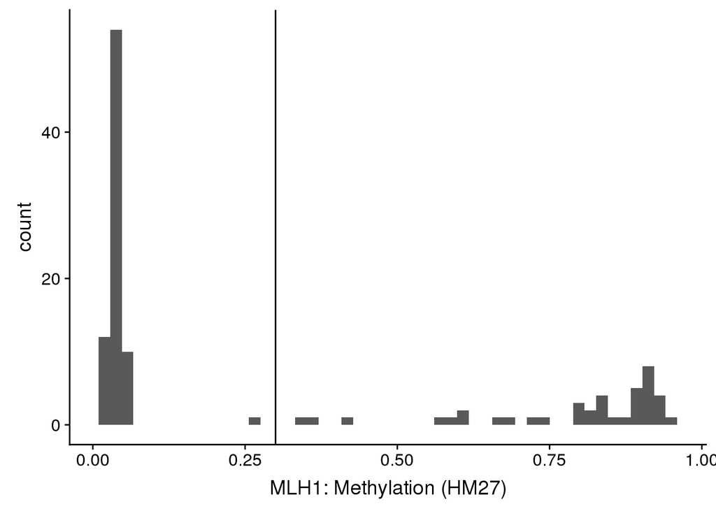

```r
MLH1me <- read_tsv("data/other/MLH1_Methylation_HM27.txt") %>% inner_join(read_tsv("data/other/MLH1_Methylation_HM450.txt")) %>%
    mutate(Variant_Classification = case_when(`MLH1: Methylation (HM450)` > 0.3 ~
        "Methylation", `MLH1: Methylation (HM27)` > 0.3 ~ "Methylation", TRUE ~ "WT")) %>%
    mutate(Gene = "MLH1") %>% dplyr::rename(submitter_id = `Patient ID`) %>% left_join(df_TCGA_sample_codes %>%
    select(testDonorPublicationID, submitter_id)) %>% dplyr::rename(TCGA_cases = testDonorPublicationID)

MLH1me %>% ggplot(aes(x = `MLH1: Methylation (HM27)`)) + geom_histogram(bins = 50) +
    geom_vline(xintercept = 0.3)
```

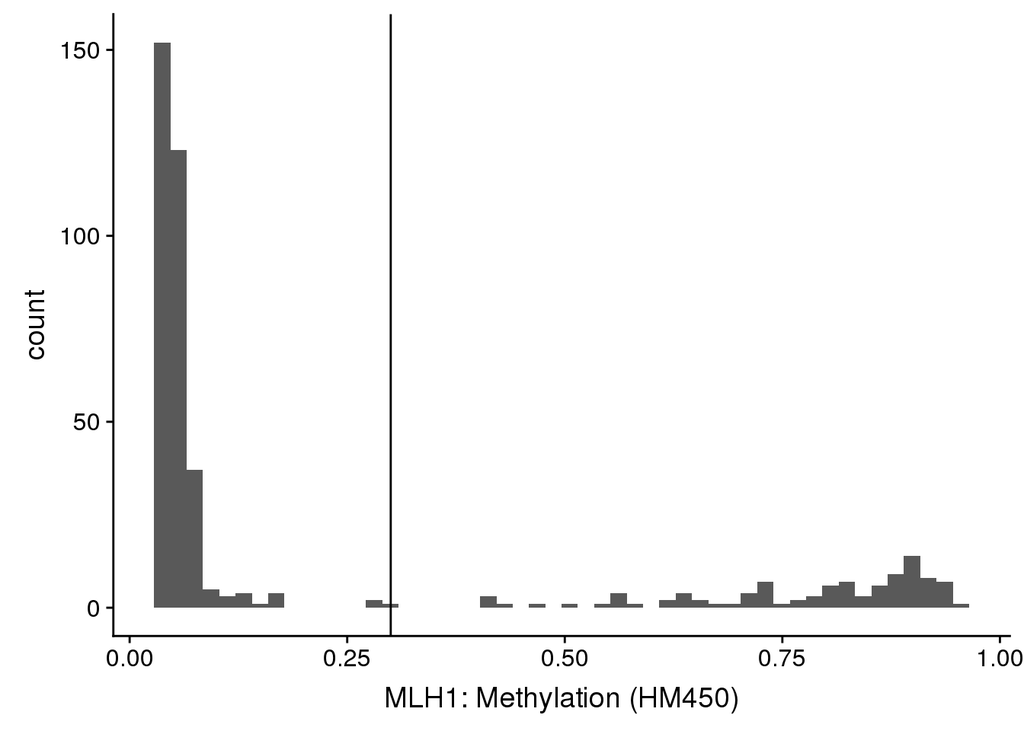

```r
MLH1me %>% ggplot(aes(x = `MLH1: Methylation (HM450)`)) + geom_histogram(bins = 50) +
    geom_vline(xintercept = 0.3)
```

```r
MSH2_del <- read_tsv("data/other/cna_MSH2.txt") %>% mutate(Variant_Classification = case_when(MSH2 ==
    "-2" ~ "Hom. Deletion", TRUE ~ "WT")) %>% mutate(submitter_id = str_remove(SAMPLE_ID,
    "-01$|-02$")) %>% mutate(Gene = "MSH2") %>% left_join(df_TCGA_sample_codes %>%
    select(testDonorPublicationID, submitter_id)) %>% dplyr::rename(TCGA_cases = testDonorPublicationID)

# Manually annotated variants with Clinvar, left only truncating and LP and P
# (removed PMS2 in psedogene region)
MMR_muts_som <- read_tsv("data/TCGA/TCGA_somatic_MMR_variants_all_annotated.txt") %>%
    filter(Include == "yes") %>% separate(Mutation, into = c("Gene"), sep = "[ ]",
    extra = "drop") %>% mutate(Variant_Classification = "Mutation") %>% select(-Include)

som_info_POLE_MMR <- som_variants_POLE %>% bind_rows(MSH2_del %>% filter(TCGA_cases %in%
    som_variants_POLE$TCGA_cases & Variant_Classification != "WT") %>% select(TCGA_cases,
    Variant_Classification, Gene)) %>% bind_rows(MLH1me %>% filter(TCGA_cases %in%
    som_variants_POLE$TCGA_cases & Variant_Classification != "WT") %>% select(TCGA_cases,
    Variant_Classification, Gene)) %>% bind_rows(MMR_muts_som) %>% select(-Mutation) %>%
    group_by(TCGA_cases, Gene) %>% distinct() %>% mutate(Variant_Classification = str_replace(Variant_Classification,
    "Missense", "Mutation")) %>% spread(key = TCGA_cases, value = Variant_Classification) %>%
    replace(is.na(.), "WT") %>% gather(key = TCGA_cases, value = Variant_Classification,
    -Gene)
```

## Prepare combined plots with mutational signatures

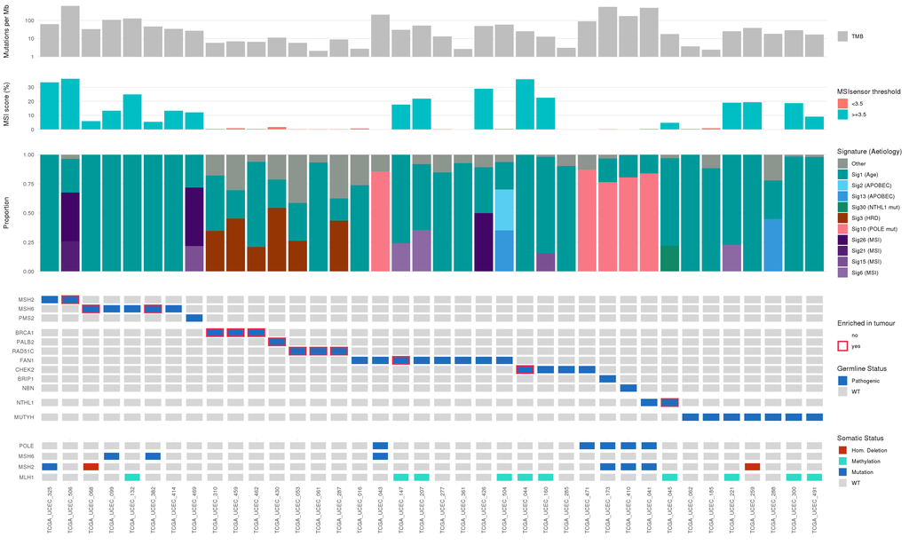

```r
sig_genes <- tibble(Gene = rev(c("MSH2", "MSH6", "PMS2", "BRCA1", "PALB2", "RAD51C",
    "FAN1", "CHEK2", "BRIP1", "NBN", "NTHL1", "MUTYH")), Group = rev(c("MMR", "MMR",
    "MMR", "HR", "HR", "HR", "HR", "HR", "HR", "HR", "NTHL1", "MUTYH"))) %>% mutate(Group = factor(Group,
    levels = rev(unique(Group)))) %>% mutate(Gene = factor(Gene, levels = rev(Gene)))

germ_vars_path <- germline_vars %>% filter(Gene %in% sig_genes$Gene) %>% group_by(Sample) %>%
    filter(!all(Type == "WT")) %>% ungroup() %>% mutate(Gene = factor(Gene, levels = rev(sig_genes$Gene))) %>%
    arrange(Type, Gene)


combined_plot(gvar = germ_vars_path, sig = sig_exome_cosmic_melt, tmb = tmb_df, svar_POLE = som_info_POLE_MMR,
    msi = msi_data, sample_order = unique(germ_vars_path$Sample), group_genes = sig_genes,
    sig_type = "cosmicv2")
```

```r
ggsave("./figures/combined_plot_path_subset_cosmicv2.pdf", height = 12, width = 20)
```

# Somatic MUTYH sample (FFPE)

Read in FFPE sample trinucleotide counts (done by Felicity Newell).

```r
ffpe_input_t <- read_tsv("./data/other/FFPE_sample_trinucleotide_counts.tsv", col_types = cols()) %>%
    mutate(sample = "FFPE") %>% spread(Trinucleotide.context, FFPE_sample) %>% column_to_rownames("sample")
```

```r
sig_ffpe <- run_deconstructsigs(data = ffpe_input_t, out_path = "./", out_name = "cosmicv2_sig_",
    signatures = cosmic_sigs, method = "default", plot = T)
```

Plot 96 trinucleotide profile for the FFPE sample.

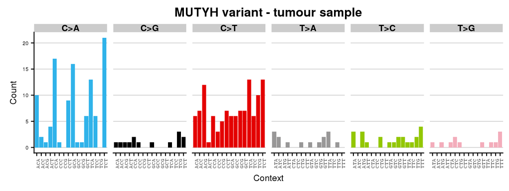

```r
ffpe_input_t %>% rownames_to_column("Sample") %>% gather("Pos", "Count", -Sample) %>%
    separate(Pos, into = c("Start", "End"), sep = ">", remove = FALSE) %>% separate(Start,
    into = c("First", "Second")) %>% separate(End, into = c("Third", "Forth")) %>%
    mutate(Context = paste0(First, Second, Forth), Pos = paste0(Second, ">", Third)) %>%
    select(-c(First, Second, Third, Forth)) %>% ggplot(.) + geom_bar(aes(x = Context,
    y = Count, fill = Pos), stat = "identity") + scale_fill_manual(values = p96_colours) +
    scale_y_continuous(labels = scales::number_format(accuracy = 1)) + facet_grid(. ~
    Pos, scales = "free_x", space = "free_x") + labs(title = "MUTYH variant - tumour sample") +
    theme(axis.text.x = element_text(angle = 90, hjust = 1, size = 6, family = "mono"),
        legend.position = "none", axis.title = element_text(size = 10), axis.text.y = element_text(size = 6),
        strip.text = element_text(size = 10, face = "bold"), panel.grid.major.y = element_line(colour = "grey80"))
```

```r
ggsave("./figures/plot96context_ffpe.pdf", width = 8, height = 3)
```

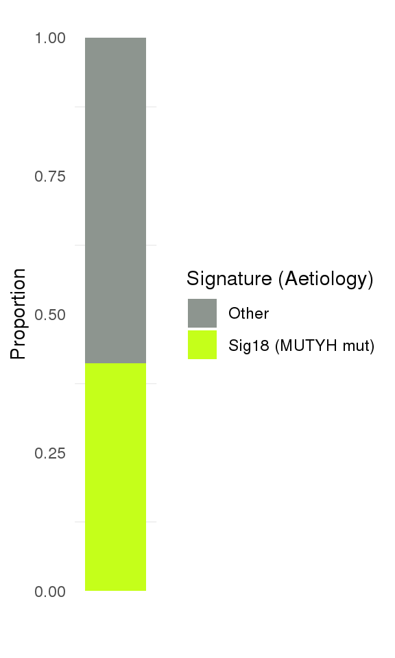

```r
sig_ffpe %>%
  mutate(Other = (1- rowSums(.[-1]))) %>% #Calculate up to 100%
  gather(Sig, Count, -Sample) %>%
  filter(Count != 0) %>%
  mutate(Sig_name = case_when(Sig == "Other" ~ "",
                              Sig == "Sig18" ~ "MUTYH mut")) %>%
  mutate(Sig_full = if_else(Sig == "Other", Sig, paste0(Sig," (",Sig_name,")"))) %>%
  ggplot(.) +
  geom_bar(aes(x= Sample, y = Count, fill = Sig_full), stat = "identity", position = "stack") +
  labs(x="",y="Proportion",fill ="Signature (Aetiology)") +
  theme_minimal(base_size = 11) +
  scale_fill_manual(values = sig_colours_cosmicv2) +
  theme(axis.text.x=element_blank(),
        strip.text.x = element_text(size = 6),
        panel.grid.major.y = element_blank(),
        panel.grid.major.x = element_blank(),
        legend.position = "right")
```

# De novo mutational signature comparison to Cosmic v2

Cosine similarity between 6 de novo signatures (SigProfiler) & Cosmic v2 30 signatures.

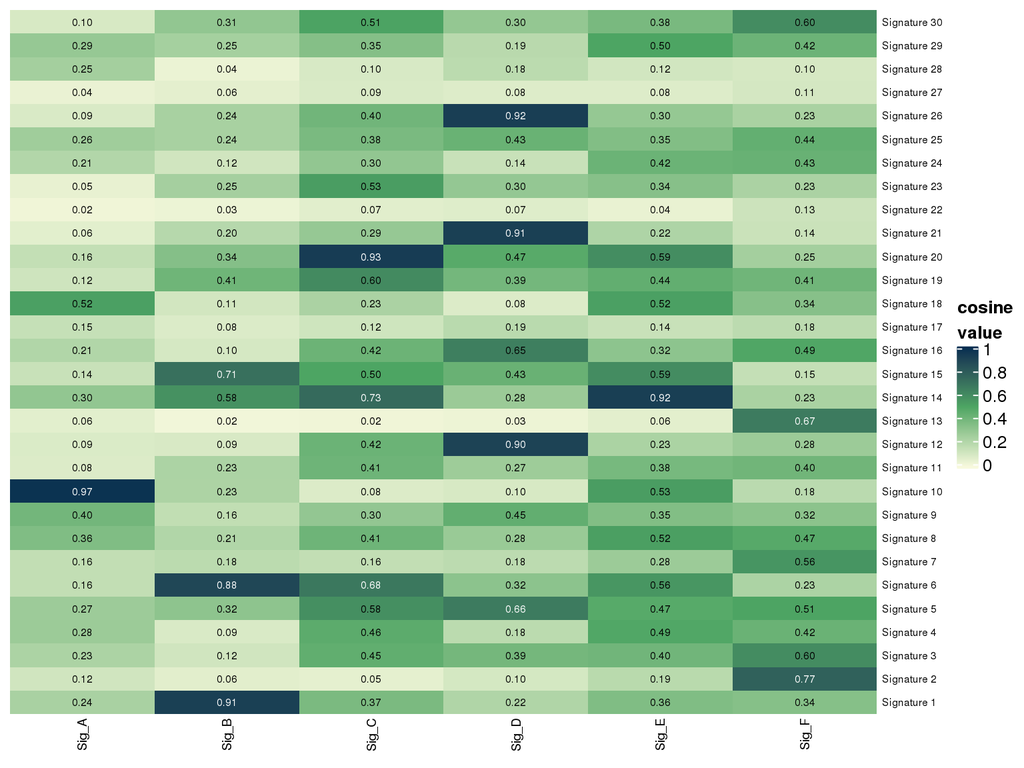

```r
de_novo_sigs_df <- read_tsv("./data/other/Signature_6.tsv", col_types = cols())

de_novo_sigs <- de_novo_sigs_df %>% mutate(base1 = substr(Subtype, start = 1, stop = 1),
    base3 = substr(Subtype, start = 3, stop = 3)) %>% mutate(context = paste0(base1,
    "[", Type, "]", base3)) %>% column_to_rownames(var = "context") %>% select(-c(base1,
    base3, Type, Subtype))

cos_sim_sig_cosmicv2 <- cos_sim_matrix(cosmic_t, de_novo_sigs)

row_order_v2 <- rev(colnames(cosmic_t))


# Plot heatmap with specified signature order
Heatmap(cos_sim_sig_cosmicv2, col = col_fun_cosine, cluster_columns = FALSE, cluster_rows = FALSE,
    clustering_method_rows = "single", row_order = row_order_v2, row_names_gp = gpar(fontsize = 6),
    column_names_gp = gpar(fontsize = 7), heatmap_legend_param = list(title = "cosine\nvalue"),
    cell_fun = function(j, i, x, y, width, height, fill) if (cos_sim_sig_cosmicv2[i,
        j] > 0.65) {
        grid.text(sprintf("%.2f", cos_sim_sig_cosmicv2[i, j]), x, y, gp = gpar(fontsize = 6,
            col = "white"))
    } else {
        grid.text(sprintf("%.2f", cos_sim_sig_cosmicv2[i, j]), x, y, gp = gpar(fontsize = 6))
    })
```

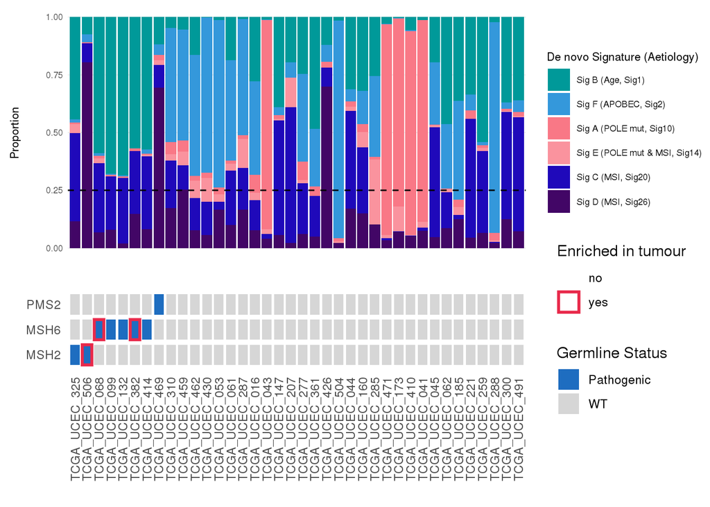

```r
de_novo_sigs_assignment <- read_csv("./data/other/Distribution_Analysis_6_Signatures.csv", col_types = cols()) %>%
  select(-ends_with("_Exposure")) %>%
  gather(key = Sig, value = Probability, -testSampleLabel) %>%
  mutate(Sig = str_remove(Sig,"_Percent"),
         Count = Probability/100) %>%
  right_join(maf_ghcc %>% select(aliquot_id,case_submitter_id) %>% distinct(),
            by=c("testSampleLabel"="aliquot_id")) %>%
  left_join(sample_list) %>%
  dplyr::rename(Sample = TCGA_cases) %>%
  mutate(Sig_full = case_when(Sig == "Sig_A" ~ "Sig A (POLE mut, Sig10)",
                              Sig == "Sig_B" ~ "Sig B (Age, Sig1)",
                              Sig == "Sig_C" ~ "Sig C (MSI, Sig20)",
                              Sig == "Sig_D" ~ "Sig D (MSI, Sig26)",
                              Sig == "Sig_E" ~ "Sig E (POLE mut & MSI, Sig14)",
                              Sig == "Sig_F" ~ "Sig F (APOBEC, Sig2)")) %>%
  mutate(Sig_full = factor(Sig_full,
                           levels = rev(sig_list_denovo))) %>%
  filter(Sample %in% germ_vars_path$Sample)


p1 <- de_novo_sigs_assignment %>%
  filter(Sample %in% unique(germ_vars_path$Sample)) %>%
  mutate(Sample = factor(Sample, levels = unique(germ_vars_path$Sample))) %>%
  ggplot(.) +
  geom_bar(aes(x= Sample, y = Count, fill = Sig_full), stat = "identity", position = "stack") +
  labs(x="",y="Proportion",fill ="De novo Signature (Aetiology)") +
  theme_minimal(base_size = 8) +
  geom_hline(yintercept = 0.25, linetype = "dashed") +
  scale_fill_manual(values = sig_colours_denovo) +
  guides(fill = guide_legend(ncol = 1)) +
  theme(axis.text.x=element_blank(),
        strip.text.x = element_text(size = 6),
        panel.grid.minor = element_blank(),
        #panel.grid.major.y = element_blank(),
        panel.grid.major.x = element_blank(),
        legend.position = "right")

p2 <- germ_vars_path %>%
  filter(Sample %in% p1$data$Sample) %>%
  filter(Gene %in% c("MSH2","MSH6","PMS2")) %>%
  mutate(Sample = factor(Sample, levels = unique(germ_vars_path$Sample))) %>%
  ggplot(.) +
  geom_tile(aes(y=Gene,x=Sample,fill=Type, colour = Enriched, width = 0.8, height = 0.8), size = 1)+
  scale_fill_manual(values = c("WT"="#d6d6d6","Pathogenic"="#1e6dc0")) +
  #scale_fill_manual(values= mut_colours) +
  scale_colour_manual(values = c("yes"="#E8294A","white")) +
  guides(color = guide_legend(ncol = 1,
                              override.aes = list(fill=NA))) +
  theme_minimal(base_size = 11) + labs(x = "", y = "", colour = "Enriched in tumour",
                                       fill = "Germline Status") +
  theme(axis.text.x=element_text(angle = 90, hjust = 1 , vjust = 0.5),
        panel.grid.major.y = element_blank(),
        panel.grid.major.x = element_blank(),
        legend.position = "right",
        strip.text.y = element_blank())

plot_grid(p1, p2, align = "v",axis = 'lr', nrow = 2, rel_heights = c(0.5,0.4))
```

```r
ggsave("./figures/denovo_sig_samples.pdf", width = 8, height = 6)
```